# Homework 1

# Solution Sample

## Part 1: Calculus

### Problem 1.1

Write an expression for the gradient of $f$,

$$ \nabla f(\mathbf{x}) = \frac{\partial f}{\partial \mathbf{x}} = \left[\begin{array}{c} \frac{\partial f}{\partial x} \\ \frac{\partial f}{\partial y} \end{array} \right]\;. $$

### Answer

$$ \nabla f(\mathbf{x}) = \left[\begin{array}{c} 3 x^2 - 6 x \\ 3 y^2 - 6 y \end{array} \right]\;. $$

### Problem 1.2

Write an expression for the Hessian of $f$,

$$ H_f(\mathbf{x}) = \frac{\partial^2 f}{\partial \mathbf{x} \partial \mathbf{x}^T} = \left[\begin{array}{cc} \frac{\partial^2 f}{\partial x^2} & \frac{\partial^2 f}{\partial x \partial y}\\ \frac{\partial^2 f}{\partial y \partial x} & \frac{\partial^2 f}{\partial y^2} \end{array} \right]\;. $$

### Answer

$$ H_f(\mathbf{x}) = \left[\begin{array}{cc} 6x - 6 & 0\\ 0 & 6y - 6 \end{array} \right]\;. $$

### Problem 1.3

Give expressions for the eigenvalues $\lambda_1 (x, y)$ and $\lambda_2(x, y)$ (in any order) of $H_f$.

### Answer

$$ \lambda_1(x, y) = 6x - 6 \;\;\;\text{and}\;\;\; \lambda_2(x, y) = 6y - 6\;. $$

### Problem 1.4

Give expressions for all the unit-norm eigenvectors $\mathbf{u}_1$ of $H_f$ corresponding to the eigenvalue $\lambda_1 (x, y)$ you found in the previous problem and for all the unit-norm eigenvectors $\mathbf{u}_2$ corresponding to the eigenvalue $\lambda_2(x, y)$.

### Answer

The eigenvector system of equations corresponding to eigenvalue $\lambda_i$ (for $i = 1, 2$) is

$$ H \mathbf{u} = \lambda_i \mathbf{u}\;. $$

When $i=1$, this system becomes (after dividing both sides by $6$)

\begin{eqnarray*} (x-1) u &=& (x-1) u\\ (y-1) v &=& (x-1) v\;. \end{eqnarray*}

The first equation is always true, and therefore if $\mathbf{u} = (u, v)^T$ then $u$ is unconstrained. The second equation admits any solution $v$ if $x = y$ and only solution $v = 0$ otherwise. In conclusion,

$$ \mathbf{u}_1 = \left\{\begin{array}{ll} \left[\begin{array}{c}\cos\alpha \\ \sin\alpha \end{array}\right] & \mbox{for any $\alpha\in [0,2\pi)$ if $x = y$} \\ \pm \left[\begin{array}{c} 1 \\ 0 \end{array}\right] & \mbox{otherwise}\;. \end{array}\right. $$

The reasoning for $\mathbf{u}_2$ is the same after simultaneously switching $x$ with $y$ and $u$ with $v$, so that

$$ \mathbf{u}_2 = \left\{\begin{array}{ll} \left[\begin{array}{c}\cos\alpha \\ \sin\alpha \end{array}\right] & \mbox{for any $\alpha\in [0,2\pi)$ if $x = y$} \\ \pm \left[\begin{array}{c} 0 \\ 1 \end{array}\right] & \mbox{otherwise}\;. \end{array}\right. $$

**Notation:** There are many correct ways to say "any unit-norm vector" (including "any unit-norm vector"), and all these earn full credit.

### Problem 1.5

Give *all* the stationary points of $f$. For each of them, state whether it is a minimum, a maximum, or a saddle point, and give unit vectors along the directions of maximum and minimum curvature (or state that curvatures in all directions are equal, if that is the case).

### Answer

Since $f$ is differentiable everywhere, the stationary points are the solutions of the system

$$ \nabla f(\mathbf{x}) = \mathbf{0} \;, $$ that is, $$ \begin{eqnarray*} x(x - 2) &=& 0 \\ y(y - 2) &=& 0 \;. \end{eqnarray*} $$

There are four solutions to this system. We reason explicitly about the first, and then give answers for all of them.

One stationary point is $\mathbf{x}_1 = (0, 0)^T$. The Hessian there is $$ H_f(\mathbf{x}_1) = -6 \left[\begin{array}{rr}1 & 0\\ 0 & 1\end{array}\right]\;. $$

Its two eigenvalues $\lambda_1 = \lambda_2 = -6$ are negative, so that the Hessian is negative definite, and $\mathbf{x}_1$ is a *maximum*. Since $x = y$ at this point, all nonzero vectors are eigenvectors, and all curvatures are the same ($-6$) at $\mathbf{x}_1$.

Similar reasoning leads to the following conclusions:

$$ \begin{array}{cccc} \mathbf{x}_k & \text{Type} & \text{Dir of max curvature} & \text{Dir of min curvature} \\\hline (0, 0)^T & \text{maximum} & \text{any} & \text{any} \\ (2, 0)^T & \text{saddle} & (\pm 1, 0)^T & (0, \pm 1)^T \\ (0, 2)^T & \text{saddle} & (0, \pm 1)^T & (\pm 1, 0)^T \\ (2, 2)^T & \text{minimum} & \text{any} & \text{any} \end{array} $$

### Problem 1.6

To check that your answers are plausible, write Python 3 code that displays a plot of 30 iso-value contours of the function $f$ for $-0.5 \leq x \leq 2.5$ and $-0.5 \leq y \leq 2.5$. Draw a red dot at every stationary point.

### Answer

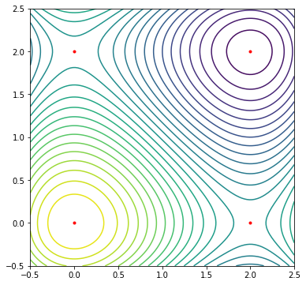

```python
import numpy as np
import matplotlib.pyplot as plt
%matplotlib inline

a, b, n = -0.5, 2.5, 101
x, y = np.linspace(a, b, n), np.linspace(a, b, n)
X, Y = np.meshgrid(x, y)
Z = X ** 3 - 3 * X ** 2 + Y ** 3 - 3 * Y ** 2
plt.figure(figsize=(6,6))
plt.contour(x, y, Z, 30)
for p in ((0, 0), (0, 2), (2, 0), (2, 2)):
    plt.plot(p[0], p[1], '.r')
plt.show()
```

## Part 2: Linear Algebra

### Problem 2.1

Give four matrices $R$, $N$, $C$, $L$ whose *rows* are bases for the row space, null space, column space (a.k.a. range), and left null space of $A$. Use rows or columns of $A$ for your basis vectors when possible, and vectors with integer entries in any case.

As a partial check, give the products $AN^T$ and $L A$ (fully spelled out with all their entries).

### Answer

$$ R = \left[\begin{array}{rrr} 1 & 0 & 1\\ 0 & 1 & -1 \end{array}\right] \;\;\;\text{,}\;\;\; N = \left[\begin{array}{rrr} -1 & 1 & 1 \end{array}\right] \;\;\;\text{,}\;\;\; C = \left[\begin{array}{rrrr} 1 & 0 & 2 & 1\\ 0 & 1 & 0 & 1 \end{array}\right] \;\;\;\text{,}\;\;\; L = \left[\begin{array}{rrrr} 1 & 1 & 0 & -1\\ 2 & 0 & -1 & 0 \end{array}\right] $$

Partial check: $$ AN^T = \left[\begin{array}{c}0\\0\\0\\0 \end{array}\right] \;\;\;\text{and}\;\;\; LA = \left[\begin{array}{ccc}0 & 0 & 0\\0 & 0 & 0 \end{array}\right] $$

### Problem 2.2

Give the set $S$ of *all* solutions to the system

$$ A \mathbf{x} = \mathbf{0} $$

where $A$ is the matrix above and $\mathbf{0}$ is a column vector of four zeros.

### Answer

All and only the vectors in the null space are solutions:

$$ S = \{\mathbf{x} \ |\ \mathbf{x} = \alpha\, (-1, 1, 1)^T \;\;\text{for}\;\; \alpha\in\mathbb{R}\} \;. $$

### Problem 2.3

Give the set $B$ of *all* vectors $\mathbf{b}$ for which the system

$$ A \mathbf{x} = \mathbf{b} $$

admits a solution, if $A$ is the matrix above.

### Answer

The system admits a solution if and only if $\mathbf{b}$ is in the column space of $A$. Thus,

$$ B = \{\mathbf{b} \ |\ \mathbf{b} = \alpha\, (1, 0, 2, 1)^T + \beta\, (0, 1, 0, 1)^T \;\;\text{for}\;\; \alpha, \beta\in\mathbb{R}\} \;. $$

## Part 3: Probability

### Problem 3.1

What are the mean $m_X$ and variance $\sigma_X^2$ of $X$?

### Answer

\begin{eqnarray*} m_X &=& 0 \cdot p_0 + 1 \cdot p_1 + 2 \cdot p_2 = 0 \cdot 0.3 + 1 \cdot 0.5 + 2 \cdot 0.2 = 0.9 \\ \sigma_X^2 &=& \mathbb{E}(X^2) - m_X^2 = 0^2 \cdot p_0 + 1^2 \cdot p_1 + 2^2 \cdot p_2 - m_X^2 \\ &=& 0 \cdot 0.3 + 1 \cdot 0.5 + 4 \cdot 0.2 - 0.9^2 = 0.49 \;. \end{eqnarray*}

### Problem 3.2

What is the mean $m_Y$ of $Y$?

### Answer

$$ m_Y = m_0 \cdot p_0 + m_1 \cdot p_1 + m_2 \cdot p_2 = 6 \cdot 0.3 + 2 \cdot 0.5 + 5 \cdot 0.2 = 3.8\;. $$

### Problem 3.3

What is the mean $m_{Y|X<2} = \mathbb{E}(Y\,|\, X < 2)$ of $Y$ given that $X < 2$?

### Answer

By definition of conditional expectation, $$ m_{Y|X<2} \;=\; \mathbb{E}(Y\,|\, X < 2) \;=\; \int_{\infty}^{\infty} y\, f_{Y|X<2}(y)\, dy $$ and \begin{eqnarray*} f_{Y|X<2}(y) &=& \frac{f(y \;\text{and either}\; X = 0 \;\text{or}\; X = 1)}{p_0 + p_1} \;=\; \frac{f((y \;\text{and}\; X = 0) \;\text{or}\; (y \;\text{and}\; X = 1))}{p_0 + p_1}\;. \end{eqnarray*} The two events at the numerator are incompatible, so their densities add up: \begin{eqnarray*} f_{Y|X<2}(y) &=& \frac{f(y \;\text{and}\; X = 0) \;+\; f(y \;\text{and}\; X = 1)}{p_0 + p_1} \\ &=& \frac{p_0\, f_{Y|X=0}(y) \;+\; p_1\, f_{Y|X=1}(y)}{p_0 + p_1} \end{eqnarray*} where the second equality uses the definition of conditional density. In conclusion, \begin{eqnarray*} m_{Y|X<2} &=& \int_{\infty}^{\infty} y\, \frac{p_0\, f_{Y|X=0}(y) \;+\; p_1\, f_{Y|X=1}(y)}{p_0 + p_1}\, dy \\ &=& \frac{p_0}{p_0 + p_1} \int_{\infty}^{\infty} y\, f_{Y|X=0}(y)\, dy \;+\; \frac{p_1}{p_0 + p_1} \int_{\infty}^{\infty} y\, f_{Y|X=1}(y)\, dy \;, \end{eqnarray*} that is, $$ m_{Y|X<2} \;=\; \frac{p_0 m_0 + p_1 m_1}{p_0 + p_1} \;=\; \frac{0.3 \cdot 6 + 0.5 \cdot 2}{0.3 + 0.5} = 3.5\;. $$

## Part 4: Python 3

```python
import numpy as np

across = ['marco', 'oneup', 'skate', 'elder', 'seeya']
puzzle = np.array([list(word) for word in across])
print(puzzle)
```

```
[['m' 'a' 'r' 'c' 'o']
 ['o' 'n' 'e' 'u' 'p']
 ['s' 'k' 'a' 't' 'e']
 ['e' 'l' 'd' 'e' 'r']
 ['s' 'e' 'e' 'y' 'a']]
```

### Problem 4.1

Write a function with header

```
def prettyPrint(p):
```

that pretty-prints any *nonempty* array like `puzzle` according to the given specifications. Show your code and the result of pretty-printing the given array `puzzle`.

### Answer

```python
def prettyPrint(p):
    assert p.ndim == 2, 'Puzzle must have two dimensions'
    for row in range(p.shape[0]):
        print(''.join(p[row]))
    print()

prettyPrint(puzzle)
```

```
marco
oneup
skate
elder
seeya
```

### Problem 4.2

Write four calls to `prettyPrint` that slice the given array `puzzle` to result in the following output:

```
mar
one

der
eya

marco

o
p
e
r
a
```

Your code should comply with the given specifications. Show code and output.

### Answer

```python
prettyPrint(puzzle[:2, :3])
prettyPrint(puzzle[-2:, -3:])
prettyPrint(np.expand_dims(puzzle[0], axis=0))
prettyPrint(np.expand_dims(puzzle[:, -1], axis=1))
```

```
mar
one

der
eya

marco

o
p
e
r
a
```

### Problem 4.3

[figure not shown]

```python
from skimage import io, color

def readGray(filename):
    img = color.rgb2gray(io.imread(filename))
    return np.around(255 * img).astype(np.uint8)

from matplotlib import pyplot as plt
%matplotlib inline

img = readGray('locomotive.jpg')
plt.imshow(img, cmap='gray')
plt.show()
```

Write a function with header

```
def cumulative(img):
```

that takes an image as produced by `readGray` and computes its cumulative distribution $c(k)$. Show your code, and plot the cumulative histogram of the image in `locomotive.jpg` as read by `readGray`.

### Answer

The implementation below assumes that pixel values are integers, but does not assume a specific number of bits. It is OK if your implementation assumes `np.uint8` and hard-wires `n` to 256. However, study this code for later reference.

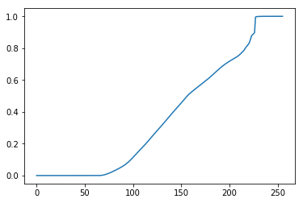

```python
def cumulative(img):
    assert np.issubdtype(img.dtype, np.unsignedinteger), \
        'image pixel type must be unsigned integer'
    n = np.iinfo(img.dtype).max + 1
    c = np.zeros(n)
    for value in img.flatten(): c[value] += 1
    for k in range(1, n): c[k] += c[k-1]
    for k in range(n): c[k] = c[k] / c[-1]
    return c

plt.plot(cumulative(img))
plt.show()
```

### Problem 4.4

If your cumulative distribution is correct, the plot should start with several values $c(k)$ equal to zero.

What do these zero values mean? In particular, how do these zeros manifest themselves visually in the image?

### Problem 4.5

Write a function with header

```
def remap(img):
```

that takes an image as returned by `readGray` and replaces the value $k$ of every pixel with value $k' = \text{round}(255\, c(k))$, where the function $c(k)$ was defined in problem 4.3.

Show your code, display the result of running `remap` on the image in `locomotive.jpg`, and plot the cumulative histogram of the remapped image.

### Answer

The loop in the `with` construct below makes `remap` agnostic to the number of dimensions of `img`. For instance, the code would work even on a color image, or on a three-dimensional image such as a computerized tomography image. For your solution, it's OK to use nested `for` loops instead. However, study this code for later reference. This code will only work in Python 3.6 or higher.

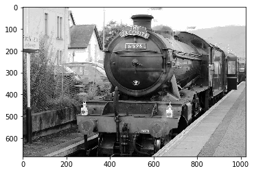

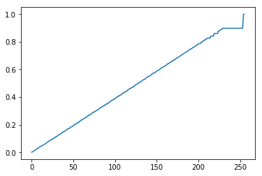

```python
def remap(img):
    table = cumulative(img)
    n = len(table)
    mx = n - 1
    for k in range(n):
        table[k] = round(mx * table[k])
    eq = np.zeros_like(img)
    with np.nditer([img, eq], op_flags=[['readonly'], ['writeonly']]) as idx:
        for x, y in idx: y[...] = table[x]
    return eq

crisp = remap(img)
plt.imshow(crisp, cmap='gray')
plt.show()

plt.plot(cumulative(crisp))
plt.show()
```

### Problem 4.6

Comment on the result. In particular, what would the *histogram* (rather than the cumulative distribution) of the remapped image look like, approximately? And in what way does the remapped *image* differ from the original, visually?

### Answer

*(This sample answer has a pedagogical purpose, and is longer and more informed than an answer that earns full credit. Parts needed for full credit are in bold.)*

The histogram $h(k)$ is the finite difference of the cumulative distribution:

$$ h(k) = \left\{\begin{array}{ll}c(0) & \mbox{for $k = 0$} \\ c(k) - c(k-1) & \mbox{otherwise.}\end{array}\right. $$

In the case in point **the histogram would look approximately uniform**. This is why the remapping function you implemented is called *histogram equalization*. **The equalized image has** a wider dynamic range, and **greater contrast** as a result.

Histogram equalization is often used as a first stage in computer vision algorithms, because high contrast makes object recognition or other tasks easier. Of course, equalization should *not* be used when the camera plays the role of a measurement device, that is, when the physical meaning of the pixel values is important.